# Practical Machine Learning

Author: Rajkumar Gupta

## Introduction

This analysis meant to be the basis for the course quiz and a prediction assignment writeup. The main goal of the project is to predict the manner in which 6 participants performed some exercise as described below. This is the “classe” variable in the training set. The machine learning algorithm described here is applied to the 20 test cases available in the test data and the predictions are submitted in appropriate format to the Course Project Prediction Quiz for automated grading.

## Environment Preparation

We first upload the R libraries that are necessary for the complete analysis.

```r
library(caret)
library(rpart)
library(rpart.plot)
library(randomForest)
library(corrplot)
set.seed(200689)
```

## Data Loading and Cleaning

Loading the dataset from the URL provided .

```r
# #URL for the download
# train_url <- "http://d396qusza40orc.cloudfront.net/predmachlearn/pml-training.csv"
# test_url  <- "http://d396qusza40orc.cloudfront.net/predmachlearn/pml-testing.csv"


# #download the datasets
# training_data <- read.csv(url(train_url))
# testing_data  <- read.csv(url(test_url))

training_data <- read.csv("pml-training.csv")
testing_data  <- read.csv("pml-testing.csv")


# dim(Train_Set)
dim(training_data)
dim(testing_data)
```

1. 19622

2. 160

1. 20

2. 160

## Cleaning Data

In this step, we will clean the dataset and get rid of observations with missing values as well as some meaningless variables.

We clean the Near Zero Variance Variables.

```r
non_zero_val <- nearZeroVar(training_data, saveMetrics = TRUE)
head(non_zero_val , 10)
```

|  | freqRatio | percentUnique | zeroVar | nzv |
| --- | --- | --- | --- | --- |
| X | 1.000000 | 100.00000000 | FALSE | FALSE |
| user_name | 1.100679 | 0.03057792 | FALSE | FALSE |
| raw_timestamp_part_1 | 1.000000 | 4.26562022 | FALSE | FALSE |
| raw_timestamp_part_2 | 1.000000 | 85.53154622 | FALSE | FALSE |
| cvtd_timestamp | 1.000668 | 0.10192641 | FALSE | FALSE |
| new_window | 47.330049 | 0.01019264 | FALSE | TRUE |
| num_window | 1.000000 | 4.37264295 | FALSE | FALSE |
| roll_belt | 1.101904 | 6.77810621 | FALSE | FALSE |
| pitch_belt | 1.036082 | 9.37722964 | FALSE | FALSE |
| yaw_belt | 1.058480 | 9.97349913 | FALSE | FALSE |

```r
training_set01 <- training_data[, !non_zero_val$nzv]
testing_set01 <- testing_data[, !non_zero_val$nzv]
dim(training_set01)
dim(testing_set01)
```

1. 19622

2. 100

1. 20

2. 100

Removing some columns of the dataset that do not contribute much to the accelerometer measurements.

```r
regex <- grepl("^X|timestamp|user_name", names(training_set01))
training <- training_set01[, !regex]
testing <- testing_set01[, !regex]
```

```r
dim(training)
```

1. 19622

2. 95

```r
dim(testing)
```

1. 20

2. 95

Removing columns that contain NA's.

```r
cond <- (colSums(is.na(training)) == 0)
training <- training[, cond]
testing <- testing[, cond]
```

## Partitioning Training Set¶

we split the cleaned training set into a pure training data set (75%) and a validation data set (25%). We will use the validation data set to conduct cross validation in future steps.

```r
set.seed(200689)
inTrain <- createDataPartition(training$classe, p = 0.75, list = FALSE)
validation <- training[-inTrain, ]
training <- training[inTrain, ]
```

```r
dim(validation)
dim(training)
```

1. 4904

2. 54

1. 14718

2. 54

The Dataset now consists of 54 variables with the observations divided as following:

```
1.Training Data: 14718 observations.
2.Validation Data: 4904 observations.
3.Testing Data: 20 observations.
```

Now, the cleaned training data set contains 19622 observations and 54 variables, while the testing data set contains 20 observations and 54 variables.

Correlation Matrix of Columns in the Training Data set.

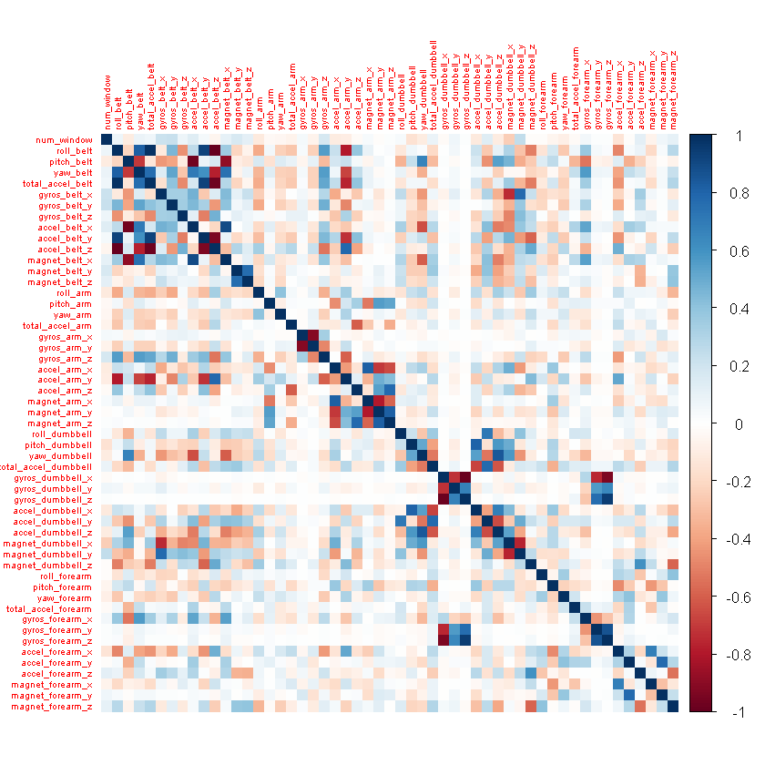

```r
corrplot(cor(training[, -length(names(training))]), method = "color", tl.cex = 0.5)
```

## 1) Method: Random Forest

```r
# model fit
set.seed(200689)
rf_control <- trainControl(method="cv", number=3, verboseIter=FALSE)
model_fit_rendom_forest <- train(classe ~ ., data=training, method="rf", trControl=rf_control)
model_fit_rendom_forest$finalModel
```

```
Call:
 randomForest(x = x, y = y, mtry = param$mtry)
               Type of random forest: classification
                     Number of trees: 500
No. of variables tried at each split: 27

        OOB estimate of  error rate: 0.22%
Confusion matrix:
     A    B    C    D    E  class.error
A 4183    2    0    0    0 0.0004778973
B    6 2838    3    1    0 0.0035112360
C    0    2 2563    2    0 0.0015582392
D    0    0   10 2401    1 0.0045605307
E    0    1    0    5 2700 0.0022172949
```

```r
# prediction on Test dataset
predict_Rand_Forest <- predict(model_fit_rendom_forest, newdata=validation)
confusion_matrix_RandForest <- confusionMatrix(predict_Rand_Forest, as.factor(validation$classe))
confusion_matrix_RandForest
```

```
Confusion Matrix and Statistics

          Reference
Prediction    A    B    C    D    E
         A 1395    0    0    0    0
         B    0  946    4    0    0
         C    0    3  851    2    0
         D    0    0    0  801    2
         E    0    0    0    1  899

Overall Statistics

               Accuracy : 0.9976
                 95% CI : (0.9957, 0.9987)
    No Information Rate : 0.2845
    P-Value [Acc > NIR] : < 2.2e-16

                  Kappa : 0.9969

 Mcnemar's Test P-Value : NA

Statistics by Class:

                     Class: A Class: B Class: C Class: D Class: E
Sensitivity            1.0000   0.9968   0.9953   0.9963   0.9978
Specificity            1.0000   0.9990   0.9988   0.9995   0.9998
Pos Pred Value         1.0000   0.9958   0.9942   0.9975   0.9989
Neg Pred Value         1.0000   0.9992   0.9990   0.9993   0.9995
Prevalence             0.2845   0.1935   0.1743   0.1639   0.1837
Detection Rate         0.2845   0.1929   0.1735   0.1633   0.1833
Detection Prevalence   0.2845   0.1937   0.1746   0.1637   0.1835
Balanced Accuracy      1.0000   0.9979   0.9970   0.9979   0.9988
```

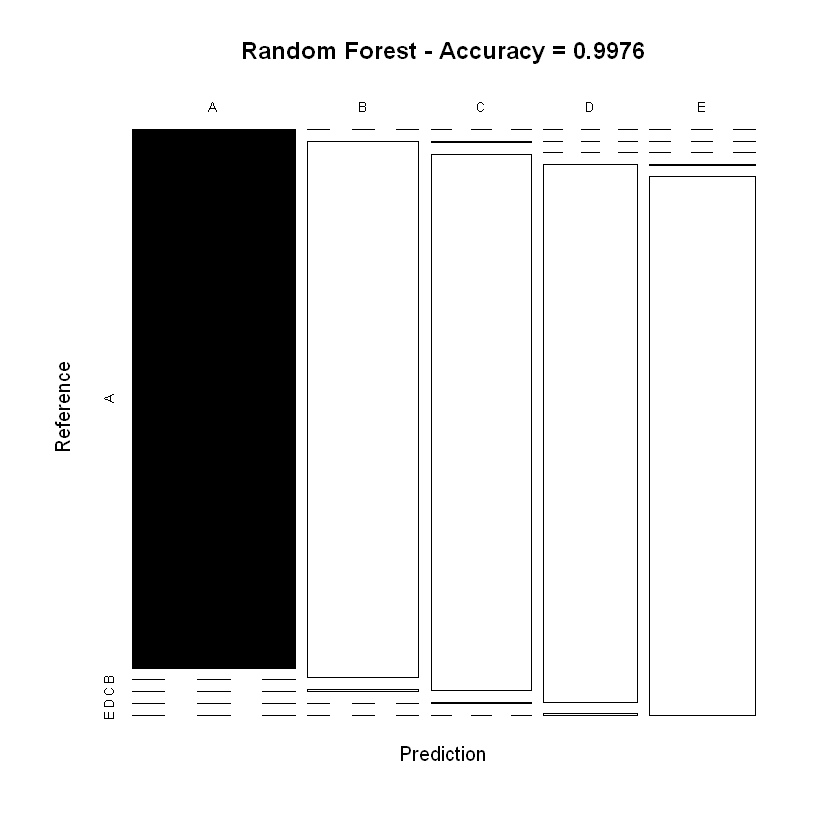

```r
# plot matrix results
plot(confusion_matrix_RandForest$table, col = confusion_matrix_RandForest$byClass,
     main = paste("Random Forest - Accuracy =",
     round(confusion_matrix_RandForest$overall['Accuracy'], 4)))
```

## 2) Method: Decision Trees

```r
# model fit
set.seed(12345)
model_fit_decision_tree <- rpart(classe ~ ., data=training, method="class")
#fancyRpartPlot(model_fit_decision_tree)
#prp(modelTree)
```

```r
# prediction on Test dataset
predict_Decision_Tree <- predict(model_fit_decision_tree, newdata=validation, type="class")
confusion_matrix_DecisonTree <- confusionMatrix(predict_Decision_Tree, as.factor(validation$classe))
confusion_matrix_DecisonTree
```

```
Confusion Matrix and Statistics

          Reference
Prediction    A    B    C    D    E
         A 1249  203   40   88   76
         B   40  551   53   33   87
         C    8   52  694  109   57
         D   77  119   43  531  116
         E   21   24   25   43  565

Overall Statistics

               Accuracy : 0.7321
                 95% CI : (0.7194, 0.7444)
    No Information Rate : 0.2845
    P-Value [Acc > NIR] : < 2.2e-16

                  Kappa : 0.6591

 Mcnemar's Test P-Value : < 2.2e-16

Statistics by Class:

                     Class: A Class: B Class: C Class: D Class: E
Sensitivity            0.8953   0.5806   0.8117   0.6604   0.6271
Specificity            0.8840   0.9461   0.9442   0.9134   0.9718
Pos Pred Value         0.7542   0.7212   0.7543   0.5993   0.8333
Neg Pred Value         0.9550   0.9039   0.9596   0.9321   0.9205
Prevalence             0.2845   0.1935   0.1743   0.1639   0.1837
Detection Rate         0.2547   0.1124   0.1415   0.1083   0.1152
Detection Prevalence   0.3377   0.1558   0.1876   0.1807   0.1383
Balanced Accuracy      0.8897   0.7634   0.8779   0.7869   0.7994
```

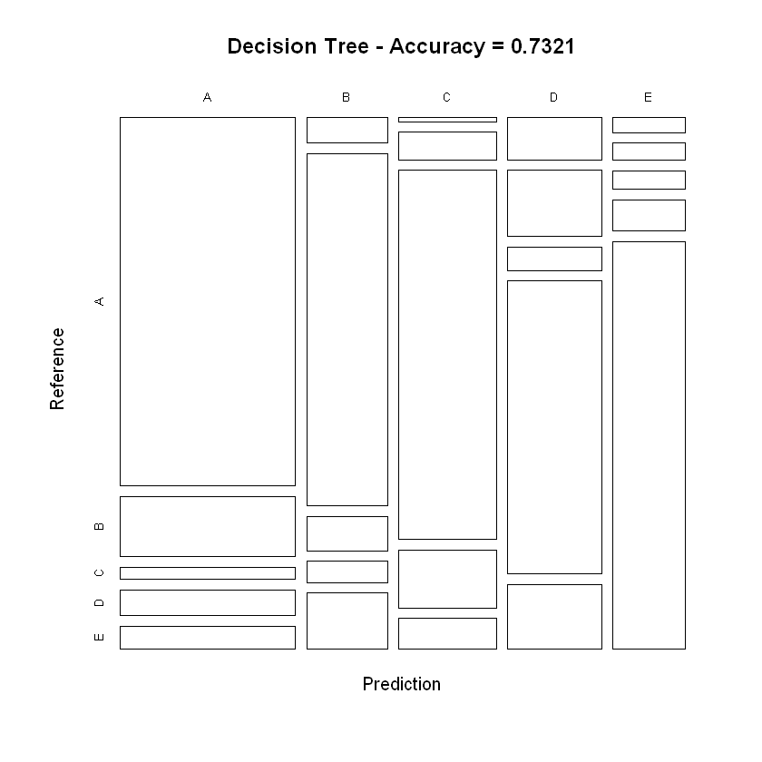

```r
# plot matrix results
plot(confusion_matrix_DecisonTree$table, col = confusion_matrix_DecisonTree$byClass,
     main = paste("Decision Tree - Accuracy =",
    round(confusion_matrix_DecisonTree$overall['Accuracy'], 4)))
```

## Applying the Selected Model to the Test Data

The accuracy of the 2 regression modeling methods above are:

1) Random Forest : 0.9976

2) Decision Tree : 0.7321

In that case, the Random Forest model will be applied to predict the 20 quiz results (testing dataset) as shown below.

```r
predictTEST <- predict(model_fit_rendom_forest, newdata=testing)
predictTEST
```

1. B

2. A

3. B

4. A

5. A

6. E

7. D

8. B

9. A

10. A

11. B

12. C

13. B

14. A

15. E

16. E

17. A

18. B

19. B

20. B

1. 'A'

2. 'B'

3. 'C'

4. 'D'

5. 'E'